# Indice de Calidad V3

David Dominguez - A01570975

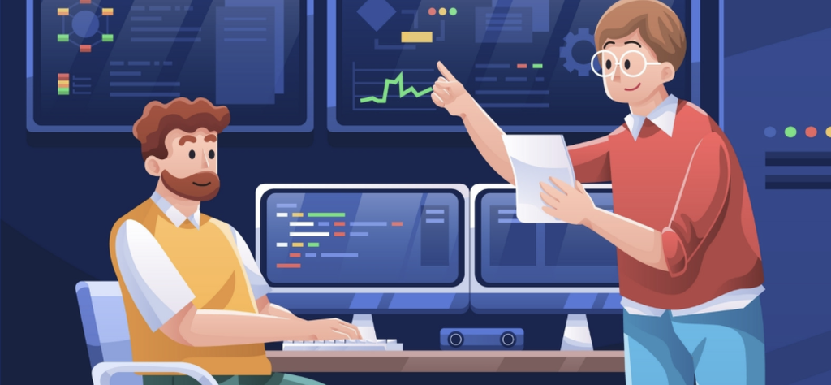

Data Quality Algorithm

# Algoritmo de Validación de Calidad

El **Algoritmo de validación de Calidad** es un modelo diseñado para unificar y automatizar los procesos de limpieza, transformación, unificación y validación de datos en la mayor medida posible. Su objetivo principal es asegurar que la información sea confiable y representativa de la realidad, facilitando la toma de decisiones basadas en datos precisos y fidedignos.

Este algoritmo forma parte del proyecto **CENSO MONITOREO 2023**, el cual propuso el uso de tecnología de reconocimiento fotográfico para habilitar a la fuerza de ventas como auditores. De esta manera, se busca recopilar información de manera eficiente, rápida y orientada a datos para tomar decisiones informadas. El programa, iniciado en septiembre de 2023, se centró inicialmente en el canal tradicional, incluyendo subcanales como abarrotes y fruterías, que son esenciales para los negocios que consumen nuestros productos a nivel nacional.

## Llamar Librerias

Esta sección está dedicada a cargar todas las librerías necesarias para ejecutar el **Algoritmo de Validación de Calidad**. Las librerías seleccionadas facilitan una amplia gama de operaciones cruciales para el procesamiento y análisis de datos:

- `dplyr`: Esencial para la manipulación y transformación eficiente de datos.
- `readr`: Permite la lectura rápida y sencilla de datos tabulares.
- `readxl`: Utilizado para importar datos desde archivos Excel.
- `tidyverse`: Un compendio de paquetes para ciencia de datos que incluye `dplyr`, `ggplot2`, entre otros, proporcionando herramientas completas para el análisis de datos.
- `fs`: Facilita el manejo del sistema de archivos.
- `purrr`: Permite la programación funcional para iterar operaciones en listas y vectores.
- `openxlsx`: Ofrece capacidades avanzadas para la lectura y escritura de archivos Excel.
- `sf`: Especializado en el manejo de datos espaciales y geográficos.
- `httr`: Esencial para la comunicación con APIs web, permitiendo interactuar con otros servicios de software.
- `jsonlite`: Maneja y procesa datos en formato JSON.
- `ggplot2`: Proporciona herramientas avanzadas para la visualización gráfica de datos.
- `stringr`: Simplifica la manipulación y gestión de texto.

Estas herramientas son fundamentales para garantizar la ejecución eficiente y efectiva del algoritmo, permitiendo una gestión de datos robusta y fiable que respalde la toma de decisiones informadas.

```r
library(dplyr)    # Manipulación de datos
library(readr)    # Lectura de datos tabulares
library(readxl)   # Lectura de archivos Excel
library(tidyverse) # Ciencia de datos (incluye dplyr, ggplot2, etc.)
library(fs)       # Manejo del sistema de archivos
library(purrr)    # Programación funcional
library(openxlsx) # Lectura/escritura de Excel avanzada
library(sf)       # Datos espaciales
library(httr)     # Comunicación con APIs web
library(jsonlite) # Trabajo con JSON
library(ggplot2)  # Visualización de datos
library(stringr)
```

## Carga de Base de Datos

La carga de bases de datos es esencial para la operación del **Algoritmo de Validación de Calidad**. Este proceso implica la recolección y combinación de diversos conjuntos de datos, cada uno crucial para distintas etapas del análisis. A continuación, se detalla la funcionalidad y el propósito de cada base de datos utilizada:

### Quality Data

Esta sección del código se encarga de combinar múltiples archivos de datos, ya sean CSV o Excel, provenientes de diferentes fuentes. El propósito es unificar esta información en un solo dataframe, aplicando transformaciones específicas como la conversión de tipos de datos para garantizar la consistencia y la integridad de la información. Las bases de datos procesadas aquí incluyen:

- **actual**: Contiene información procesada de reconocimiento fotográfico con los facings de productos de Arca Continental y otros.
- **session**: Registra datos de cada sesión de toma de fotos, incluyendo el usuario, el cliente, y las coordenadas geográficas.
- **survey**: Filtra los datos de la sesión por tipo de encuesta, centrándose en censo y otros tipos específicos.
- **scenes**: Detalla el tipo de foto tomada, como imágenes de refrigeradores o estantes, clasificando si son de ambiente o enfriadores.

```r
setwd("fuentes_datos/")  # Establecer ruta de trabajo

# Función para leer y combinar archivos de una carpeta
combine_files <- function(path, file_type = c("csv", "excel")) {

  # Obtener lista de archivos en el directorio especificado
  files <- list.files(path, full.names = TRUE)

  df_combined <- data.frame()

  process_file <- function(file) {
  tryCatch({
    if (grepl("\\.csv$", file)) {
      data <- read_csv(file)
    } else if (grepl("\\.(xlsx|xls|XLSX|XLS)$", file)) {
      data <- read_excel(file)
    } else {
      stop("Tipo de archivo no soportado")
    }

    # Lista de columnas que deben ser double
    cols_to_double <- c("Duration(Sec)", "longitude", "latitude", "SessionEndLongitude", "SessionEndLatitude")

    # Convertir todas las columnas a character, excepto las especificadas
    data[] <- lapply(names(data), function(col) {
      if (col %in% cols_to_double) {
        as.numeric(as.character(data[[col]]))
      } else {
        as.character(data[[col]])
      }
    })

    return(data)
  }, error = function(e) {
    print(paste("Error al procesar el archivo:", file))  # Imprimir el archivo con error
    print(e)  # Imprimir el error específico
    return(NULL)
  })
}

  if ("csv" %in% file_type) {
    files_csv <- grep("\\.csv$", files, value = TRUE)
    if(length(files_csv) > 0){
      df_list_csv <- lapply(files_csv, process_file)
      df_combined <- bind_rows(df_combined, do.call(bind_rows, df_list_csv))
    }
  }

  if ("excel" %in% file_type) {
    files_xls <- grep("\\.(xlsx|xls|XLSX|XLS)$", files, value = TRUE)
    if(length(files_xls) > 0){
      df_list_xls <- lapply(files_xls, process_file)
      df_combined <- bind_rows(df_combined, do.call(bind_rows, df_list_xls))
    }
  }

  # Eliminar filas duplicadas
  if(nrow(df_combined) > 0) {
    df_combined <- df_combined %>% distinct()
  }

  return(df_combined)
}

# Crear data frames para cada carpeta
df_actual <- combine_files("actual/")
df_session <- combine_files("session/")
df_survey <- combine_files("survey/")
df_scenes <- combine_files("scenes/")
```

### Query Como Dato

Esta subsección se concentra en procesar datos específicos de comodato, es decir, información relacionada con el número de enfriadores por cliente. Utiliza una serie de transformaciones para sumarizar la cantidad de artículos por cliente, lo cual es vital para análisis posteriores sobre la distribución y uso de recursos en puntos de venta.

```r
# Lista de todos los archivos Excel en el directorio
files <- dir("fuentes_datos/comodato", pattern = "\\.xlsx$", full.names = TRUE)

# Lee cada archivo y combínalos en un solo dataframe
df_comodato <- files %>%
  map_dfr(~ read_xlsx(.x))
# Agrupa por Código Cliente y suma # de Artículos
df_poc <- df_comodato %>%
  group_by(`Código Cliente`) %>%
  summarise(Total_Articulos = sum(`# de Articulos`, na.rm = TRUE)) %>%
  ungroup()

# Verifica el resultado
head(df_poc)
```

```
## # A tibble: 6 × 2
##   `Código Cliente` Total_Articulos
##   <chr>                      <dbl>
## 1 #ERROR                         5
## 2 11012054                       1
## 3 500146176                     19
## 4 500147348                      2
## 5 500147349                      2
## 6 500147350                     37
```

### Master Clientes

El código aquí presente está destinado a crear un ‘master’ de clientes a partir de varios archivos, los cuales se limpian y estandarizan para asegurar una nomenclatura consistente. Este ‘master’ es fundamental para realizar cruces de datos y análisis demográficos o de mercado sobre los clientes. Combina y deduplica registros para formar una base robusta y actualizada de información cliente.

```r
# Función para limpiar y estandarizar nombres de columnas
limpiar_nombres <- function(df){
  names(df) <- tolower(names(df))
  names(df) <- chartr("áéíóú", "aeiou", names(df))
  names(df) <- gsub(" ", "_", names(df))
  return(df)
}

# Leer todos los archivos en la carpeta
read_all_files <- function(path) {
  files <- list.files(path, full.names = TRUE, pattern = "\\.xlsx$")
  dfs <- lapply(files, read_xlsx)
  names(dfs) <- gsub(".xlsx", "", basename(files))
  return(dfs)
}

# Leer todos los archivos en fuentes_datos/clientes, excepto el de clientes que leeremos directamente
all_dfs <- read_all_files("fuentes_datos/clientes")

# Leer y limpiar los archivos Excel
clientes_trad <- read_xlsx("fuentes_datos/clientes/Catálogo Clientes MX TRAD + C&B.xlsx") %>% limpiar_nombres()
omd_censo <- read_xlsx("fuentes_datos/clientes/OMD Censo México NOV23.xlsx") %>% limpiar_nombres()

# Convertir PostalCode a character si existe en ambos dataframes
if("postalcode" %in% names(clientes_trad) && "postalcode" %in% names(omd_censo)) {
  clientes_trad$postalcode <- as.character(clientes_trad$postalcode)
  omd_censo$postalcode <- as.character(omd_censo$postalcode)
}

# Combinar los archivos
clientes_combinados <- bind_rows(clientes_trad, omd_censo)

# Eliminar duplicados, manteniendo el último (de omd_censo)
clientes_unicos <- clientes_combinados %>%
  arrange(desc(customercode)) %>%
  distinct(customercode, .keep_all = TRUE)

# Aplica limpiar nombres a las tablas en all_dfs
all_dfs <- lapply(all_dfs, function(df) {
  names(df) <- limpiar_nombres(names(df))
  return(df)
})

# Tomar el dataframe 'mds' de all_dfs:
mds <- all_dfs[["Clientes"]]  # Ajusta el nombre según corresponda si es diferente

# Elimina registros duplicados en mds basados en codigo_cliente
mds <- mds %>%
  limpiar_nombres() %>%
  group_by(codigo_cliente) %>%
  filter(row_number() == 1) %>%
  ungroup()

# Creación de la columna 'tamaño' en 'mds'
mds <- mds %>%
  mutate(
    tamaño = ifelse(canal_rgm == "Comer y Beber",
                    tamaño_de_cliente,
                    tamaño_de_cliente_industria)
  ) %>%
  mutate(tamaño = tolower(tamaño)) %>%
  mutate(
    tamaño = case_when(
      tamaño == "micro" ~ "MI",
      tamaño == "pequeño" ~ "CH",
      tamaño == "mediano" ~ "M",
      tamaño == "grande" ~ "G",
      tamaño == "extra grande" ~ "XG",
      TRUE ~ tamaño
    )
  )

# Hacer el left_join con clientes
master_clientes <- clientes_unicos %>%
  left_join(mds[, c("codigo_cliente", "tamaño", "sub_canal_isscom", "modelo_de_servicio_ruta", "ruta_preventa_oficial", "zona...13", "territorio...14")],
            by = c("customercode" = "codigo_cliente"))

# Verificar el resultado
head(master_clientes)
```

```
## # A tibble: 6 × 86
##   country subclientcode subclient customercode    barcode customername    street
##   <chr>   <chr>         <lgl>            <dbl>      <dbl> <chr>           <chr>
## 1 Mexico  Arca México   NA          8700092558 8700092558 MARISCOS EL REY <NA>
## 2 Mexico  Arca México   NA          8700092492 8700092492 AGENCIA CORONA… <NA>
## 3 Mexico  Arca México   NA          8700092392 8700092392 REICING CAR WA… <NA>
## 4 Mexico  Arca México   NA          8700092314 8700092314 CONAGUA         <NA>
## 5 Mexico  Arca México   NA          8700092313 8700092313 AGENCIA KIA     <NA>
## 6 Mexico  Arca México   NA          8700092310 8700092310 TORRE MEDICA L… <NA>
## # ℹ 79 more variables: address2 <lgl>, address3 <lgl>, address4 <lgl>,
## #   city <chr>, state <chr>, postalcode <chr>, regioncode <lgl>,
## #   regionname <lgl>, latitude <dbl>, longitude <dbl>, timezone <chr>,
## #   primaryphone <lgl>, mobilephone <lgl>, email <lgl>,
## #   salesorganizationcode <chr>, salesorganizationname <chr>,
## #   salesofficecode <chr>, salesofficename <chr>, salesgroupcode <chr>,
## #   salesgroupname <chr>, salesterritorycode <chr>, salesterritory <chr>, …
```

### Parametros

Finalmente, esta sección carga parámetros específicos que son necesarios para el funcionamiento del algoritmo. Estos parámetros pueden incluir configuraciones, límites y otros valores clave que influyen en el procesamiento y análisis de los datos.

```r
# Cargar la hoja "data" del archivo "parametros"
parametros_data <- read_excel("parametros.xlsx", sheet = "data")

# Verificar la carga de datos
head(parametros_data)
```

```
## # A tibble: 6 × 17
##   tradechannelcode sub_canal_isscom                  tamaño lower_bound_duration
##   <chr>            <chr>                             <chr>                 <dbl>
## 1 Tradicional      ABARROTES                         CH                     1.67
## 2 Comer y Beber    BAR / TABERNA / CANTINA           CH                     1.67
## 3 Comer y Beber    CAFETERÍA/NEVERÍA/FUENTE DE SODA… CH                     1.67
## 4 Tradicional      CARNICERÍA, POLLERÍA O PESCADERÍA CH                     1.67
## 5 Tradicional      FARMACIA INDEPENDIENTE            CH                     1.67
## 6 Comer y Beber    FONDA / LONCHERÍA / MERENDEROS    CH                     1.67
## # ℹ 13 more variables: upper_bound_duration <dbl>, lower_bound_frentes <dbl>,
## #   upper_bound_frentes <dbl>, lower_bound_enfriadores <dbl>,
## #   upper_bound_enfriadores <dbl>, lower_bound_NumScenes <dbl>,
## #   upper_bound_NumScenes <dbl>, lower_bound_ScenesAmb <dbl>,
## #   upper_bound_ScenesAmb <dbl>, lower_bound_ScenesFrio <dbl>,
## #   upper_bound_ScenesFrio <dbl>, lower_bound_frentes_arca <dbl>,
## #   upper_bound_frentes_arca <dbl>
```

Cada una de estas bases de datos juega un rol crucial en asegurar que el **Algoritmo de Validación de Calidad** funcione de manera óptima, proporcionando resultados precisos y confiables para la toma de decisiones basada en datos.

## Sabana de Analisis

Esta sección aborda el análisis detallado de los datos recolectados, enfocándose en tres aspectos principales: tiempo, coordenadas y frentes. Cada subsección aplica transformaciones y cálculos específicos para extraer métricas clave que apoyan la interpretación y las decisiones basadas en los datos.

### Tiempo

En esta subsección, convertimos la duración de las encuestas de segundos a minutos para facilitar la interpretación. Además, creamos una variable binaria que indica si el estatus de la encuesta es ‘Completa’. Estas transformaciones permiten analizar más eficientemente el tiempo dedicado a cada sesión y su finalización.

```r
df_survey <- df_survey %>%
  mutate(duration = `Duration(Sec)` / 60) %>%
  mutate(estatus = if_else(Status == "Complete", 1, 0))

# Verificar los cambios
head(df_survey)
```

```
##   Survey Id                          Session Uid Client Reference ID
## 1  23440973 4f8957aa-2aba-4dc3-953e-6df1b8c077a8                <NA>
## 2  23435400 c6c80f9e-7439-4f0c-aaef-747914fda4e4                <NA>
## 3  23435390 83edf421-a427-4194-9628-3ba3b5b51137                <NA>
## 4  23435388 686b95d9-f162-4032-8cc2-91402d626320                <NA>
## 5  23420798 b86e0c85-e50f-42f2-9c5e-075475cc5aff                <NA>
## 6  23419783 096cc310-57c7-4388-a727-6aa246479a3c                <NA>
##       Survey Type             Survey Date       Survey Start Time
## 1 CENSO 2023 TRAD 21/04/2024 18:00:00 CST 22/04/2024 19:04:53 CST
## 2 CENSO 2023 TRAD 17/04/2024 18:00:00 CST 18/04/2024 09:12:19 CST
## 3 CENSO 2023 TRAD 18/04/2024 18:00:00 CST 19/04/2024 11:27:30 CST
## 4 CENSO 2023 TRAD 18/04/2024 18:00:00 CST 19/04/2024 11:23:43 CST
## 5 CENSO 2023 TRAD 21/04/2024 18:00:00 CST 22/04/2024 14:46:10 CST
## 6 CENSO 2023 TRAD 21/04/2024 18:00:00 CST 22/04/2024 08:54:35 CST
##           Survey End Time Duration(Sec)   Status Total Questions  Latitude
```

[output cut: 34 more lines]

### Coordenadas - ()

Calculamos la distancia entre dos puntos geográficos utilizando la fórmula del haversine, que es esencial para entender la dispersión geográfica de las sesiones y clientes. Posteriormente, integramos datos de clientes para calcular estas distancias y identificar valores atípicos, los cuales se reemplazan por 0 para normalizar el análisis.

```r
# Función del haversine para calcular distancia entre dos puntos de latitud y longitud
haversine <- function(lon1, lat1, lon2, lat2) {
  R <- 6371000  # Radio de la Tierra en metros
  phi1 <- lat1 * (pi / 180)
  phi2 <- lat2 * (pi / 180)
  delta_phi <- (lat2 - lat1) * (pi / 180)
  delta_lambda <- (lon2 - lon1) * (pi / 180)

  a <- sin(delta_phi / 2)^2 + cos(phi1) * cos(phi2) * sin(delta_lambda / 2)^2
  c <- 2 * atan2(sqrt(a), sqrt(1 - a))

  d <- R * c  # Distancia en metros
  return(d)
}

# Convertir las columnas relevantes a character
df_session$OutletCode <- as.character(df_session$OutletCode)
master_clientes$customercode <- as.character(master_clientes$customercode)

# Realizar el join y calcular la distancia usando la función haversine
df_session <- df_session %>%
  left_join(select(master_clientes, customercode, latitude, longitude),
            by = c("OutletCode" = "customercode")) %>%
  mutate(
    distance = mapply(haversine, longitude, latitude, SessionEndLongitude, SessionEndLatitude)
  )

# Calculamos los cuartiles y el rango intercuartil de la distancia
Q1 <- quantile(df_session$distance, 0.25, na.rm = TRUE)
Q3 <- quantile(df_session$distance, 0.75, na.rm = TRUE)
IQR <- Q3 - Q1

# Reemplazar valores atípicos por 0
df_session$distance[df_session$distance < (Q1 - 1.5 * IQR) |
                    df_session$distance > (Q3 + 1.5 * IQR)] <- 0

# Identificar valores atípicos
outliers <- df_session$distance[df_session$distance < (Q1 - 1.5 * IQR) |
                                df_session$distance > (Q3 + 1.5 * IQR)]

# Imprimir valores atípicos
print(outliers)
```

[output not shown]

```r
# Verificar los cambios
head(df_session)
```

```
##         ID                           SessionUId SessionStartDateTime
## 1 23187954 0874d91f-47e0-4aed-b30b-c70ff0db3afe  2024-04-18 14:02:06
## 2 23187623 8e00911e-e5ff-4270-9a95-f450a2d9d43d  2024-04-18 19:21:32
## 3 23138858 6e696890-3a3d-4d85-8a7e-f992ec7b113c  2024-04-17 20:29:50
## 4 23135796 47906716-786f-4f89-a0e2-7f10b58b427e  2024-04-17 20:02:50
## 5 23170263 0c157695-53cc-45b3-897f-3403db2aa94f  2024-04-18 14:45:39
## 6 23142861 0da00a3b-d2d0-45bc-82c5-f969cab95611  2024-04-17 16:19:08
##        SessionEndDateTime    ProgramId
## 1 2024-04-18 19:18:27.887         3155
## 2 2024-04-18 20:04:15.093     31553010
## 3 2024-04-17 20:55:15.843         3155
## 4  2024-04-17 20:10:42.95 413342092431
## 5  2024-04-18 14:58:13.22         3155
## 6 2024-04-17 17:50:41.327         3155
##                                                                                       ProgramName
```

[output cut: 90 more lines]

### Frentes - (CHECK)

Esta subsección evalúa la presencia y el tipo de productos en puntos de venta, calculando el número de frentes de productos propios y competidores. También determinamos el SOVI (Share of Voice Index), que mide la visibilidad de la marca en relación con los competidores.

```r
frentes_df <- df_actual %>%
  group_by(SessionUID) %>%
  summarise(
    # Cálculo de num_frentes
    num_frentes = sum(ProductName != "Foreign" & IsEmpty == FALSE),
    # Cálculo de frentes_com
    frentes_com = sum(ProductName != "Foreign" & IsForeign == TRUE),
    # Cálculo de frentes_total
    frentes_total = sum(ProductName != "Foreign" & IsEmpty == FALSE)
  ) %>%
  mutate(
    # Cálculo de frentes_arca
    frentes_arca = frentes_total - frentes_com,
    # Cálculo de sovi
    sovi = ifelse(frentes_total == 0, 0, frentes_arca / frentes_total)
  )

# Verificar el nuevo dataframe
head(frentes_df)
```

```
## # A tibble: 6 × 6
##   SessionUID            num_frentes frentes_com frentes_total frentes_arca  sovi
##   <chr>                       <int>       <int>         <int>        <int> <dbl>
## 1 000a2221-1cda-4a43-b…         353           1           353          352 0.997
## 2 000c621a-27ba-4f70-9…          37           0            37           37 1
## 3 00144659-afa8-43c0-b…         105           4           105          101 0.962
## 4 0025ffb3-9f99-4626-8…          45           0            45           45 1
## 5 003c1a72-4d01-46f2-b…          12           0            12           12 1
## 6 003fa8db-c572-4a9f-b…          28           0            28           28 1
```

### Enfriadores

```r
result_enfriadores <- df_scenes %>%
  # Agrupar por SessionUID y SubSceneType y contar
  group_by(SessionUID, SubSceneType) %>%
  count() %>%
  # Transforma valores de SubSceneType en columnas individuales
  spread(key = SubSceneType, value = n, fill = 0) %>% # fill = 0 para llenar con 0s donde no haya conteos
  ungroup()

# Funcion para sumar Enfriadores

# Genera las columnas si no existen
if (!"Enfriador AC" %in% names(result_enfriadores)) {
  result_enfriadores$`Enfriador AC` <- 0
}
if (!"Enfriador AC CEDIDO" %in% names(result_enfriadores)) {
  result_enfriadores$`Enfriador AC CEDIDO` <- 0
}

# Suma las columnas
result_enfriadores <- result_enfriadores %>%
  mutate(enfriador_total = `Enfriador AC` + `Enfriador AC CEDIDO`)

# Verificar el resultado
head(result_enfriadores)
```

```
## # A tibble: 6 × 43
##   SessionUID                       `AC – Otra plataforma` AC – Plataforma Comi…¹
##   <chr>                                             <dbl>                  <dbl>
## 1 000a2221-1cda-4a43-bf95-579a380…                      0                      0
## 2 000c621a-27ba-4f70-90bc-1e3fd9c…                      0                      0
## 3 00144659-afa8-43c0-b171-543ce58…                      0                      0
## 4 00212997-c648-414d-acfa-040c2c8…                      0                      0
## 5 0025ffb3-9f99-4626-8daf-33b83cb…                      0                      0
## 6 002b153c-c60e-400e-8cc1-77e0d19…                      0                      0
## # ℹ abbreviated name: ¹`AC – Plataforma Comidas`
## # ℹ 40 more variables: `AC – Plataforma Desayuno` <dbl>,
## #   `AC – Plataforma Hidratación` <dbl>, Ambiente <dbl>, Anaquel <dbl>,
## #   `Anaquel Cliente` <dbl>, `Anaquel Comidas` <dbl>, `Anaquel Desayuno` <dbl>,
## #   `Anaquel Hidratación` <dbl>, `Cámara Fría` <dbl>, `Chuponera AC` <dbl>,
## #   `Chuponera Cliente` <dbl>, `Chuponera Competencia` <dbl>, Copete <dbl>,
## #   `Enfriador AC` <dbl>, `Enfriador AC CEDIDO` <dbl>, …
```

### Scenes

En esta subsección, combinamos datos de `df_actual` con `df_scenes` para enriquecer el análisis de las escenas capturadas con el tipo de subescena. Calculamos el número de frentes por cada tipo de subescena y aplicamos filtros para identificar escenas con significancia estadística, excluyendo ciertos tipos bajo criterios específicos.

```r
# Unir df_actual con df_scenes para obtener SubSceneType en df_actual
df_actual_con_scenes <- df_actual %>%
  left_join(df_scenes %>% select(SceneUID, SubSceneType), by = "SceneUID")

# Calcular Frentes por SceneUID con SubSceneType ahora disponible
df_frentes <- df_actual_con_scenes %>%
  group_by(SceneUID, SubSceneType) %>%
  summarise(frentes = n_distinct(ProductName[ProductName != "Foreign" & IsEmpty == FALSE]),
            .groups = 'drop') %>%
  mutate(es_chuponera = grepl("Chuponera", SubSceneType))

# Filtrar escenas por número de frentes, excluyendo "Chuponeras" del criterio de más de 5 frentes
df_filtrado <- df_frentes %>%
  filter((!es_chuponera & frentes > 5) | es_chuponera)

# Paso 1: Crear df con SceneUID, MaxDoorIndex, y SessionUID basado en df_actual
df_actual_maxdoorindex <- df_actual %>%
  group_by(SceneUID) %>%
  summarise(MaxDoorIndex = max(DoorIndex, na.rm = TRUE), .groups = 'drop') %>%
  left_join(df_actual %>% select(SceneUID, SessionUID) %>% distinct(), by = "SceneUID")

# Paso 2: Hacer join con df_scenes para agregar SceneType
df_joined <- df_actual_maxdoorindex %>%
  left_join(df_scenes %>% select(SceneUID, SceneType) %>% distinct(), by = "SceneUID")

# Unir con df_filtrado que incluye el filtro de frentes
df_joined_con_frentes <- df_joined %>%
  inner_join(df_filtrado %>% select(SceneUID, es_chuponera, frentes), by = "SceneUID")

# Paso 3: Usar df_joined_con_frentes para calcular la cantidad de escenas de cada tipo y el total por SessionUID
df_summary <- df_joined_con_frentes %>%
  group_by(SessionUID) %>%
  summarise(Total_Scenes = n(),
            Ambiente_Scenes = sum(SceneType == "AMBIENTE"),
            Frio_Scenes = sum(SceneType == "FRIO"),
            .groups = 'drop') %>%
  replace_na(list(Ambiente_Scenes = 0, Frio_Scenes = 0)) # Reemplazar NA con 0

# Mostrando el dataframe final con el filtro aplicado
head(df_summary)
```

```
## # A tibble: 6 × 4
##   SessionUID                           Total_Scenes Ambiente_Scenes Frio_Scenes
##   <chr>                                       <int>           <int>       <int>
## 1 000a2221-1cda-4a43-bf95-579a38051ae6            5               3           2
## 2 000c621a-27ba-4f70-90bc-1e3fd9c6c4cc            1               0           1
## 3 00144659-afa8-43c0-b171-543ce5835159            1               0           1
## 4 0025ffb3-9f99-4626-8daf-33b83cbff711            1               0           1
## 5 003c1a72-4d01-46f2-bc62-8296fa732eab            1               0           1
## 6 003fa8db-c572-4a9f-baa3-95c56c07ded4            1               0           1
```

### Flags

Esta subsección se dedica a la detección y manejo de ‘flags’ o indicadores en la calidad de imagen. Procesamos la columna `ImageQuality` para identificar y resumir los flags detectados, aplicando una lógica específica para transformar y analizar estos datos, lo cual es crucial para garantizar la integridad y utilidad de las imágenes en análisis posteriores.

```r
# Creación del vector de valores de flag
flag_values <- c(2, 4, 13, 14, 15, 16, 26, 27, 32, 36, 39, 31)
#-------------------------------------------------------------

# Función para dividir la cadena en pares y añadir comas
format_image_quality <- function(value) {
  # Divide la cadena en pares de caracteres
  split_values <- str_extract_all(value, ".{1,2}")[[1]]
  # Une los valores con comas
  paste(split_values, collapse = ",")
}

# Aplica la función a la columna ImageQuality
df_scenes$ImageQuality <- sapply(df_scenes$ImageQuality, format_image_quality)

# Ahora procede con la agrupación y concatenación
result_scenes <- df_scenes %>%
  group_by(SessionUID) %>%
  summarise(ImageQuality = paste(unique(ImageQuality), collapse = ",")) %>%
  ungroup()

#--------------------------------------------------------------
# Función para detectar las flags en la columna ImageQuality
detect_flags <- function(quality_string) {
  quality_values <- as.numeric(unlist(strsplit(quality_string, ",")))  # Divide la cadena y convierte a numéricos
  detected <- quality_values[quality_values %in% flag_values]
  if(length(detected) > 0) {
    return(paste(detected, collapse = ","))
  } else {
    return(NA_character_)
  }
}

# Función para comprobar si alguno de los valores de flag está en la columna ImageQuality
check_flags <- function(quality_string) {
  quality_values <- as.numeric(unlist(strsplit(quality_string, ",")))  # Divide la cadena y convierte a numéricos

  if(any(quality_values %in% flag_values)) {
    return(-100)
  } else {
    return(100)
  }
}

# Aplicar ambas funciones a la columna ImageQuality de result_scenes
result_scenes$flag_trigger <- sapply(result_scenes$ImageQuality, check_flags)
result_scenes$detected_flags <- sapply(result_scenes$ImageQuality, detect_flags)

# Verificar el resultado
head(result_scenes)
```

```
## # A tibble: 6 × 4
##   SessionUID                           ImageQuality flag_trigger detected_flags
##   <chr>                                <chr>               <dbl> <chr>
## 1 000a2221-1cda-4a43-bf95-579a38051ae6 -1                    100 <NA>
## 2 000c621a-27ba-4f70-90bc-1e3fd9c6c4cc -1                    100 <NA>
## 3 00144659-afa8-43c0-b171-543ce5835159 -1                    100 <NA>
## 4 00212997-c648-414d-acfa-040c2c80df20 -1                    100 <NA>
## 5 0025ffb3-9f99-4626-8daf-33b83cbff711 -1                    100 <NA>
## 6 002b153c-c60e-400e-8cc1-77e0d198859a -1                    100 <NA>
```

### Cuotas

Esta subsección calcula y asigna las cuotas diarias a los clientes según el modelo de servicio de ruta al que están asignados. Las cuotas son esenciales para establecer metas y expectativas de ventas y servicio diario, reflejando las estrategias operativas y comerciales para diferentes tipos de rutas. A continuación, se detalla cómo se determina la cuota para cada tipo de ruta:

- **PRE ESPECIALIZADA**: 3
- **PREVENTA 24**: 2
- **PREVENTA 48 FORANEO**: 1
- **PRE MDO TRADICIONAL**: 2
- **PRE MICRO MERCADOS**: 3
- **PREVENTA 72 FOR**: 1
- **PREVENTA 48 METROPOLITANO**: 1
- **PRE COMERCIAL**: 2
- **PREVENTA NCBS**: 3

Estas cuotas permiten ajustar las operaciones y recursos necesarios para cada ruta y tipo de cliente, optimizando el rendimiento y la efectividad del equipo de ventas.

```r
master_clientes <- master_clientes %>%
  mutate(
    cuota_diaria = case_when(
      modelo_de_servicio_ruta == "PRE ESPECIALIZADA" ~ 3,
      modelo_de_servicio_ruta == "PREVENTA 24" ~ 2,
      modelo_de_servicio_ruta == "PREVENTA 48 FORANEO" ~ 1,
      modelo_de_servicio_ruta == "PRE MDO TRADICIONA" ~ 2,
      modelo_de_servicio_ruta == "PRE MICRO MERCADOS" ~ 3,
      modelo_de_servicio_ruta == "PREVENTA 72 FOR" ~ 1,
      modelo_de_servicio_ruta == "PREVENTA 48 METROPOLITANO" ~ 1,
      modelo_de_servicio_ruta == "PRE COMERCIAL" ~ 2,
      modelo_de_servicio_ruta == "PREVENTA NCBS" ~ 3,
      TRUE ~ NA_real_
    )
  )

# Verificar el resultado
head(master_clientes)
```

```
## # A tibble: 6 × 87
##   country subclientcode subclient customercode    barcode customername    street
##   <chr>   <chr>         <lgl>     <chr>             <dbl> <chr>           <chr>
## 1 Mexico  Arca México   NA        8700092558   8700092558 MARISCOS EL REY <NA>
## 2 Mexico  Arca México   NA        8700092492   8700092492 AGENCIA CORONA… <NA>
## 3 Mexico  Arca México   NA        8700092392   8700092392 REICING CAR WA… <NA>
## 4 Mexico  Arca México   NA        8700092314   8700092314 CONAGUA         <NA>
## 5 Mexico  Arca México   NA        8700092313   8700092313 AGENCIA KIA     <NA>
## 6 Mexico  Arca México   NA        8700092310   8700092310 TORRE MEDICA L… <NA>
## # ℹ 80 more variables: address2 <lgl>, address3 <lgl>, address4 <lgl>,
## #   city <chr>, state <chr>, postalcode <chr>, regioncode <lgl>,
## #   regionname <lgl>, latitude <dbl>, longitude <dbl>, timezone <chr>,
## #   primaryphone <lgl>, mobilephone <lgl>, email <lgl>,
## #   salesorganizationcode <chr>, salesorganizationname <chr>,
## #   salesofficecode <chr>, salesofficename <chr>, salesgroupcode <chr>,
## #   salesgroupname <chr>, salesterritorycode <chr>, salesterritory <chr>, …
```

## Empalme de Información

Esta sección se centra en la gestión y combinación de datos históricos con datos recientes, lo cual es crucial para realizar análisis longitudinales y mantener la consistencia y continuidad de la información a lo largo del tiempo.

### Cargar Data Historica

Inicialmente, verificamos y cargamos todos los archivos históricos disponibles en un formato estructurado. Esto incluye asegurar que las identificaciones de los puntos de venta sean tratadas como caracteres para mantener la integridad de los datos. Los datos históricos se seleccionan y preparan con una serie de columnas específicas para futuros análisis y comparaciones.

```r
# Ruta a la carpeta con archivos históricos procesados
ruta_carpeta <- "data_procesada/"

# Verificar si hay archivos históricos
archivos_historicos <- list.files(path = ruta_carpeta, pattern = "\\.csv$", full.names = TRUE)

if (length(archivos_historicos) > 0) {
  # Cargar y combinar todos los archivos históricos en un dataframe
  datos_historicos <- map_dfr(archivos_historicos, function(file) {
    datos <- read_csv(file)
    datos$`Outlet Code` <- as.character(datos$`Outlet Code`)  # Asegurar que Outlet Code sea siempre un carácter
    select(datos,
      SessionUID, SurveyType, User, `Outlet Code`,
      salesorganizationcode, tamaño, tradechannelcode, sub_canal_isscom,
      duration, distance,
      frentes_total, frentes_arca, sovi, flag_trigger, enfriador_total,
      Total_Scenes, Ambiente_Scenes, Frio_Scenes, detected_flags,
      modelo_de_servicio_ruta, salesterritorycode, territorio, `Survey End Time`, estatus
    )
  })
} else {
  # Inicializar un dataframe vacío con las columnas esperadas
  datos_historicos <- tibble(
    SessionUID = character(), SurveyType = character(), User = character(), `Outlet Code` = character(),
    salesorganizationcode = character(), tamaño = character(), tradechannelcode = character(), sub_canal_isscom = character(),
    duration = numeric(), distance = numeric(),
    frentes_total = numeric(), frentes_arca = numeric(), sovi = numeric(), flag_trigger = numeric(), enfriador_total = numeric(),
    Total_Scenes = numeric(), Ambiente_Scenes = numeric(), Frio_Scenes = numeric(), detected_flags = character(),
    modelo_de_servicio_ruta = character(), salesterritorycode = character(), territorio = character(), `Survey End Time` = Date(), estatus = numeric()
  )
}
```

### Data Nueva e Historica Combinada

Después de preparar los datos históricos, procedemos a integrarlos con los datos nuevos recolectados en encuestas recientes. Esto asegura que tengamos un conjunto de datos completo y actualizado, con `Survey End Time` estandarizado a tipo fecha, permitiendo análisis temporales precisos y efectivos.

```r
# Preparar datos nuevos de df_survey con las columnas relevantes
nuevos_datos_survey <- df_survey %>%
  mutate(
    `Survey End Time` = as.Date(substr(`Survey End Time`, 1, 10), format = "%d/%m/%Y"),
    SessionUID = `Session Uid`,
    SurveyType = `Survey Type`,
    duration = duration
  ) %>%
  select(
    SessionUID, SurveyType, User, `Outlet Code`, duration, `Survey End Time`, estatus
  )

# Combinar datos históricos con nuevos datos de survey, ahora ambos con 'Survey End Time' como tipo Date
datos_combinados <- bind_rows(datos_historicos, nuevos_datos_survey) %>%
  distinct(SessionUID, .keep_all = TRUE)
```

## Sabana Calidad Semilla

Esta sección se encarga de imputar datos faltantes en el conjunto de datos combinado utilizando información de varias fuentes para garantizar la integridad y la completitud de los datos. Las imputaciones se realizan en campos clave que son críticos para el análisis posterior y la toma de decisiones.

```r
# Imputaciones desde df_session para 'distance'
datos_combinados <- datos_combinados %>%
  mutate(
    distance = ifelse(is.na(distance),
                      df_session$distance[match(SessionUID, df_session$SessionUId)],
                      distance)
  )

# Imputaciones desde frentes_df para 'frentes_total', 'frentes_arca', y 'sovi'
datos_combinados <- datos_combinados %>%
  mutate(
    frentes_total = ifelse(is.na(frentes_total),
                           frentes_df$frentes_total[match(SessionUID, frentes_df$SessionUID)],
                           frentes_total),
    frentes_arca = ifelse(is.na(frentes_arca),
                          frentes_df$frentes_arca[match(SessionUID, frentes_df$SessionUID)],
                          frentes_arca),
    sovi = ifelse(is.na(sovi),
                  frentes_df$sovi[match(SessionUID, frentes_df$SessionUID)],
                  sovi)
  )

# Imputaciones desde result_scenes para 'flag_trigger' y 'detected_flags'
datos_combinados <- datos_combinados %>%
  mutate(
    flag_trigger = ifelse(is.na(flag_trigger),
                          result_scenes$flag_trigger[match(SessionUID, result_scenes$SessionUID)],
                          flag_trigger),
    detected_flags = ifelse(is.na(detected_flags),
                            result_scenes$detected_flags[match(SessionUID, result_scenes$SessionUID)],
                            detected_flags)
  )

# Imputaciones desde result_enfriadores para 'enfriador_total'
datos_combinados <- datos_combinados %>%
  mutate(
    enfriador_total = ifelse(is.na(enfriador_total),
                             result_enfriadores$enfriador_total[match(SessionUID, result_enfriadores$SessionUID)],
                             enfriador_total)
  )

# Imputaciones para datos de clientes
datos_combinados <- datos_combinados %>%
  mutate(
    tamaño = ifelse(is.na(tamaño),
                    master_clientes$tamaño[match(`Outlet Code`, master_clientes$customercode)],
                    tamaño),
    salesorganizationcode = ifelse(is.na(salesorganizationcode),
                                   master_clientes$salesorganizationcode[match(`Outlet Code`, master_clientes$customercode)],
                                   salesorganizationcode),
    tradechannelcode = ifelse(is.na(tradechannelcode),
                              master_clientes$tradechannelcode[match(`Outlet Code`, master_clientes$customercode)],
                              tradechannelcode),
    sub_canal_isscom = ifelse(is.na(sub_canal_isscom),
                              master_clientes$sub_canal_isscom[match(`Outlet Code`, master_clientes$customercode)],
                              sub_canal_isscom),
    modelo_de_servicio_ruta = ifelse(is.na(modelo_de_servicio_ruta),
                                     master_clientes$modelo_de_servicio_ruta[match(`Outlet Code`, master_clientes$customercode)],
                                     modelo_de_servicio_ruta),
    salesterritorycode = ifelse(is.na(salesterritorycode),
                                master_clientes$salesterritorycode[match(`Outlet Code`, master_clientes$customercode)],
                                salesterritorycode),
    territorio = ifelse(is.na(territorio),
                        master_clientes$`territorio...14`[match(`Outlet Code`, master_clientes$customercode)],
                        territorio)
  )

# Imputaciones desde df_summary para 'Total_Scenes', 'Ambiente_Scenes', y 'Frio_Scenes'
datos_combinados <- datos_combinados %>%
  mutate(
    Total_Scenes = ifelse(is.na(Total_Scenes),
                          df_summary$Total_Scenes[match(SessionUID, df_summary$SessionUID)],
                          Total_Scenes),
    Ambiente_Scenes = ifelse(is.na(Ambiente_Scenes),
                             df_summary$Ambiente_Scenes[match(SessionUID, df_summary$SessionUID)],
                             Ambiente_Scenes),
    Frio_Scenes = ifelse(is.na(Frio_Scenes),
                         df_summary$Frio_Scenes[match(SessionUID,df_summary$SessionUID)],
Frio_Scenes)
)

master_calidad <- datos_combinados
```

### Eliminar Directorio

Después de consolidar los datos necesarios, limpiamos los directorios para mantener un entorno de trabajo organizado y eficiente. Esta práctica asegura que solo se retengan los archivos esenciales, facilitando la gestión de datos y la prevención de errores de procesamiento debido a la presencia de archivos obsoletos o innecesarios.

```r
# Función para limpiar directorio de archivos individuales, manteniendo solo el combinado
clean_directory <- function(path) {
  combined_file_path <- file.path(path, "combined.csv")

  # Listar todos los archivos excepto el archivo combinado
  files_to_delete <- setdiff(list.files(path, full.names = TRUE), combined_file_path)

  # Eliminar archivos
  file.remove(files_to_delete)
}

# Limpiar directorios de archivos individuales
clean_directory("fuentes_datos/session/")
```

```
## [1] TRUE TRUE TRUE TRUE
```

```r
clean_directory("fuentes_datos/survey/")
```

```
## [1] TRUE
```

```r
clean_directory("fuentes_datos/actual/")
```

```
## [1] TRUE TRUE TRUE TRUE
```

```r
clean_directory("fuentes_datos/scenes/")
```

```
## [1] TRUE TRUE TRUE TRUE
```

## Correción de Datos

### Flags Inducidas

En esta subsección, implementamos correcciones específicas para las flags en los datos, basándonos en criterios predeterminados que reflejan inconsistencias o condiciones anómalas en los datos. Estas correcciones son críticas para mantener la integridad de los análisis y asegurar que las decisiones basadas en estos datos sean sólidas y fiables.

```r
# 1. Contar los SceneUID distintos para cada SessionUID
scene_count_df <- df_actual %>%
  group_by(SessionUID) %>%
  summarise(min_frentes = n_distinct(SceneUID) * 3)

# Unir temporalmente con master_calidad para aplicar las condiciones
master_calidad_temp <- left_join(master_calidad, scene_count_df, by = "SessionUID")

# Actualizar las flags de acuerdo con las condiciones
master_calidad <- master_calidad_temp %>%
  mutate(
    # Flag para 0 frentes totales
    detected_flags = ifelse(frentes_total == 0,
                            ifelse(is.na(detected_flags), "66", paste(detected_flags, ",66", sep="")),
                            detected_flags),
    flag_trigger = ifelse(frentes_total == 0, -100, flag_trigger),
    # Flag para frentes insuficientes
    detected_flags = ifelse(frentes_total < min_frentes,
                            ifelse(is.na(detected_flags), "61", paste(detected_flags, ",61", sep="")),
                            detected_flags),
    flag_trigger = ifelse(frentes_total < min_frentes, -100, flag_trigger),
    # Nueva flag para enfriador_total no nulo y frentes_total nulo
    detected_flags = ifelse(!is.na(enfriador_total) & is.na(frentes_total),
                            ifelse(is.na(detected_flags), "-100", paste(detected_flags, ",-100", sep="")),
                            detected_flags),
    flag_trigger = ifelse(!is.na(enfriador_total) & is.na(frentes_total), -100, flag_trigger)
  ) %>%
  select(-min_frentes)  # Eliminamos la columna temporal min_frentes

head(master_calidad)
```

```
## # A tibble: 6 × 24
##   SessionUID         SurveyType User  `Outlet Code` salesorganizationcode tamaño
##   <chr>              <chr>      <chr> <chr>         <chr>                 <chr>
## 1 4f8957aa-2aba-4dc… CENSO 202… PVTA… 500103207     Occidente             CH
## 2 c6c80f9e-7439-4f0… CENSO 202… PVTA… 500139756     Norte                 MI
## 3 83edf421-a427-419… CENSO 202… PVTA… 500139937     Norte                 MI
## 4 686b95d9-f162-403… CENSO 202… PVTA… 510958467     Norte                 <NA>
## 5 b86e0c85-e50f-42f… CENSO 202… PVTA… 510614631     Occidente             <NA>
## 6 096cc310-57c7-438… CENSO 202… REPA… 500545322     Occidente             MI
## # ℹ 18 more variables: tradechannelcode <chr>, sub_canal_isscom <chr>,
## #   duration <dbl>, distance <dbl>, frentes_total <int>, frentes_arca <int>,
## #   sovi <dbl>, flag_trigger <dbl>, enfriador_total <dbl>, Total_Scenes <int>,
## #   Ambiente_Scenes <int>, Frio_Scenes <int>, detected_flags <chr>,
## #   modelo_de_servicio_ruta <chr>, salesterritorycode <chr>, territorio <chr>,
## #   `Survey End Time` <date>, estatus <dbl>
```

## Evaluación de Data

### Union con Base de Datos de Parametros

Esta subsección del análisis se centra en enriquecer y evaluar la calidad del conjunto de datos maestro (`master_calidad`) a través de la incorporación de parámetros externos. Estos parámetros pueden incluir variables críticas que afectan la interpretación y el análisis posterior de los datos, tales como categorías de tamaño, canales comerciales y sub-canales específicos. La unión se realiza mediante campos clave que incluyen el tamaño del cliente, el código del canal comercial y el sub-canal.

```r
# Paso 1: Unión con parametros_data
master_evaluado <- master_calidad %>%
  left_join(parametros_data, by = c("tamaño", "tradechannelcode", "sub_canal_isscom"))

# Paso 2: Generar subconjuntos basados en combinaciones de tradechannelcode, tamaño y sub_canal_isscom "General"
comer_beber_MI <- parametros_data[parametros_data$tradechannelcode == "Comer y Beber" & parametros_data$tamaño == "MI" & parametros_data$sub_canal_isscom == "General", ]
comer_beber_CH <- parametros_data[parametros_data$tradechannelcode == "Comer y Beber" & parametros_data$tamaño == "CH" & parametros_data$sub_canal_isscom == "General", ]
comer_beber_M  <- parametros_data[parametros_data$tradechannelcode == "Comer y Beber" & parametros_data$tamaño == "M"  & parametros_data$sub_canal_isscom == "General", ]
comer_beber_G  <- parametros_data[parametros_data$tradechannelcode == "Comer y Beber" & parametros_data$tamaño == "G"  & parametros_data$sub_canal_isscom == "General", ]
comer_beber_XG <- parametros_data[parametros_data$tradechannelcode == "Comer y Beber" & parametros_data$tamaño == "XG" & parametros_data$sub_canal_isscom == "General", ]

tradicional_MI <- parametros_data[parametros_data$tradechannelcode == "Tradicional" & parametros_data$tamaño == "MI" & parametros_data$sub_canal_isscom == "General", ]
tradicional_CH <- parametros_data[parametros_data$tradechannelcode == "Tradicional" & parametros_data$tamaño == "CH" & parametros_data$sub_canal_isscom == "General", ]
tradicional_M  <- parametros_data[parametros_data$tradechannelcode == "Tradicional" & parametros_data$tamaño == "M"  & parametros_data$sub_canal_isscom == "General", ]
tradicional_G  <- parametros_data[parametros_data$tradechannelcode == "Tradicional" & parametros_data$tamaño == "G"  & parametros_data$sub_canal_isscom == "General", ]
tradicional_XG <- parametros_data[parametros_data$tradechannelcode == "Tradicional" & parametros_data$tamaño == "XG" & parametros_data$sub_canal_isscom == "General", ]
```

### Imputación de Parametros

Esta sección detalla el proceso de imputación de valores faltantes para parámetros clave utilizando un enfoque basado en la combinación de segmentos de negocio y tamaños de clientes. Estas imputaciones son críticas para completar el dataset antes de proceder a análisis más profundos, asegurando que todos los registros tengan parámetros completos que reflejen las condiciones operativas y de mercado.

```r
# Corrección del Paso 2 y 3: Usar bucle para iterar sobre columnas y reemplazar NAs
cols_to_modify <- c("lower_bound_frentes", "upper_bound_frentes",
                    "lower_bound_enfriadores","upper_bound_enfriadores",
                    "lower_bound_duration", "upper_bound_duration","lower_bound_ScenesFrio", "upper_bound_ScenesFrio",  "lower_bound_frentes_arca", "upper_bound_frentes_arca", "lower_bound_ScenesAmb", "upper_bound_ScenesAmb", "lower_bound_NumScenes", "upper_bound_NumScenes")

for(col in cols_to_modify) {

  # Comer y Beber
  master_evaluado[[col]] <- ifelse(is.na(master_evaluado[[col]]) & master_evaluado$tradechannelcode == "Comer y Beber" & master_evaluado$tamaño == "MI", comer_beber_MI[[col]], master_evaluado[[col]])
  master_evaluado[[col]] <- ifelse(is.na(master_evaluado[[col]]) & master_evaluado$tradechannelcode == "Comer y Beber" & master_evaluado$tamaño == "CH", comer_beber_CH[[col]], master_evaluado[[col]])
  master_evaluado[[col]] <- ifelse(is.na(master_evaluado[[col]]) & master_evaluado$tradechannelcode == "Comer y Beber" & master_evaluado$tamaño == "M",  comer_beber_M[[col]],  master_evaluado[[col]])
  master_evaluado[[col]] <- ifelse(is.na(master_evaluado[[col]]) & master_evaluado$tradechannelcode == "Comer y Beber" & master_evaluado$tamaño == "G",  comer_beber_G[[col]],  master_evaluado[[col]])
  master_evaluado[[col]] <- ifelse(is.na(master_evaluado[[col]]) & master_evaluado$tradechannelcode == "Comer y Beber" & master_evaluado$tamaño == "XG", comer_beber_XG[[col]], master_evaluado[[col]])

    # Tradicional
  master_evaluado[[col]] <- ifelse(is.na(master_evaluado[[col]]) & master_evaluado$tradechannelcode == "Tradicional" & master_evaluado$tamaño == "MI", tradicional_MI[[col]], master_evaluado[[col]])
  master_evaluado[[col]] <- ifelse(is.na(master_evaluado[[col]]) & master_evaluado$tradechannelcode == "Tradicional" & master_evaluado$tamaño == "CH", tradicional_CH[[col]], master_evaluado[[col]])
  master_evaluado[[col]] <- ifelse(is.na(master_evaluado[[col]]) & master_evaluado$tradechannelcode == "Tradicional" & master_evaluado$tamaño == "M",  tradicional_M[[col]],  master_evaluado[[col]])
  master_evaluado[[col]] <- ifelse(is.na(master_evaluado[[col]]) & master_evaluado$tradechannelcode == "Tradicional" & master_evaluado$tamaño == "G",  tradicional_G[[col]],  master_evaluado[[col]])
  master_evaluado[[col]] <- ifelse(is.na(master_evaluado[[col]]) & master_evaluado$tradechannelcode == "Tradicional" & master_evaluado$tamaño == "XG", tradicional_XG[[col]], master_evaluado[[col]])

  # Para los NA en tradechannelcode
  master_evaluado[[col]] <- ifelse(is.na(master_evaluado[[col]]) & is.na(master_evaluado$tradechannelcode), tradicional_M[[col]], master_evaluado[[col]])

  # Caso donde tamaño es NA pero tradechannelcode es "Comer y Beber"
  master_evaluado[[col]] <- ifelse(is.na(master_evaluado[[col]]) & is.na(master_evaluado$tamaño) & master_evaluado$tradechannelcode == "Comer y Beber", comer_beber_M[[col]], master_evaluado[[col]])

  # Caso donde tamaño es NA pero tradechannelcode es "Tradicional"
  master_evaluado[[col]] <- ifelse(is.na(master_evaluado[[col]]) & is.na(master_evaluado$tamaño) & master_evaluado$tradechannelcode == "Tradicional", tradicional_M[[col]], master_evaluado[[col]])
}
```

### Remplazo de NA y Evaluación según Cluster

Esta parte del análisis asegura que todos los datos tengan valores completos mediante una imputación final, usando valores de referencia del segmento ‘Tradicional M’ para cualquier NA restante. Posteriormente, se califican distintas características de los datos basándose en rangos específicos definidos por parámetros, lo que permite evaluar la calidad de los datos de manera cuantitativa.

```r
# Paso 4
# Imputación final para reemplazar cualquier NA restante con los valores de 'tradicional_M'
for(col in cols_to_modify) {
  master_evaluado[[col]] <- ifelse(is.na(master_evaluado[[col]]), tradicional_M[[col]], master_evaluado[[col]])
}

# Paso 5: Calificación
master_evaluado <- master_evaluado %>%
  mutate(
    # Calificación para frentes_total
    score_frentes_total = case_when(
      frentes_total >= lower_bound_frentes & frentes_total <= upper_bound_frentes ~ 100,
      frentes_total >= (lower_bound_frentes - 0.1 * (upper_bound_frentes - lower_bound_frentes)) &
        frentes_total <= (upper_bound_frentes + 0.1 * (upper_bound_frentes - lower_bound_frentes)) ~ 50,
      TRUE ~ 0
    ),
    # Calificación para frentes_total
    score_frentes_arca = case_when(
      frentes_arca >= lower_bound_frentes_arca & frentes_arca <= upper_bound_frentes_arca ~ 100,
      frentes_arca >= (lower_bound_frentes_arca - 0.01 * (upper_bound_frentes_arca - lower_bound_frentes_arca)) &
        frentes_arca <= (upper_bound_frentes_arca + 0.01 * (upper_bound_frentes_arca - lower_bound_frentes_arca)) ~ 50,
      TRUE ~ 0
    ),
    # Calificación para duration
    score_duration = case_when(
      duration >= lower_bound_duration & duration <= upper_bound_duration ~ 100,
      duration >= (lower_bound_duration - 0.1 * (upper_bound_duration - lower_bound_duration)) &
        duration <= (upper_bound_duration + 0.1 * (upper_bound_duration - lower_bound_duration)) ~ 50,
      TRUE ~ 0
    ),
    # Calificación para enfriador_total
    score_enfriador_total = case_when(
      enfriador_total >= lower_bound_enfriadores & enfriador_total <= upper_bound_enfriadores ~ 100,
      enfriador_total >= (lower_bound_enfriadores - 0.1 * (upper_bound_enfriadores - lower_bound_enfriadores)) &
        enfriador_total <= (upper_bound_enfriadores + 0.1 * (upper_bound_enfriadores - lower_bound_enfriadores)) ~ 50,
      TRUE ~ 0
    ),
    # Calificación para Num.Scenes
    score_NumScenes = case_when(
      Total_Scenes >= lower_bound_NumScenes & Total_Scenes <= upper_bound_NumScenes ~ 100,
      Total_Scenes >= (lower_bound_NumScenes - 0.1 * (upper_bound_NumScenes - lower_bound_NumScenes)) &
        Total_Scenes <= (upper_bound_NumScenes + 0.1 * (upper_bound_NumScenes - lower_bound_NumScenes)) ~ 50,
      TRUE ~ 0
    ),
    # Calificación para Scenes_Amb
    score_ScenesAmb = case_when(
      Ambiente_Scenes >= lower_bound_ScenesAmb & Ambiente_Scenes <= upper_bound_ScenesAmb ~ 100,
      Ambiente_Scenes >= (lower_bound_ScenesAmb - 0.1 * (upper_bound_ScenesAmb - lower_bound_ScenesAmb)) &
        Ambiente_Scenes <= (upper_bound_ScenesAmb + 0.1 * (upper_bound_ScenesAmb - lower_bound_ScenesAmb)) ~ 50,
      TRUE ~ 0
    ),
    # Calificación para Scenes_Frio
    score_ScenesFrio = case_when(
      Frio_Scenes >= lower_bound_ScenesFrio & Frio_Scenes <= upper_bound_ScenesFrio ~ 100,
      Frio_Scenes >= (lower_bound_ScenesFrio - 0.1 * (upper_bound_ScenesFrio - lower_bound_ScenesFrio)) &
        Frio_Scenes <= (upper_bound_ScenesFrio + 0.1 * (upper_bound_ScenesFrio - lower_bound_ScenesFrio)) ~ 50,
      TRUE ~ 0
    )
  )

# Verificar el resultado
head(master_evaluado)
```

```
## # A tibble: 6 × 45
##   SessionUID         SurveyType User  `Outlet Code` salesorganizationcode tamaño
##   <chr>              <chr>      <chr> <chr>         <chr>                 <chr>
## 1 4f8957aa-2aba-4dc… CENSO 202… PVTA… 500103207     Occidente             CH
## 2 c6c80f9e-7439-4f0… CENSO 202… PVTA… 500139756     Norte                 MI
## 3 83edf421-a427-419… CENSO 202… PVTA… 500139937     Norte                 MI
## 4 686b95d9-f162-403… CENSO 202… PVTA… 510958467     Norte                 <NA>
## 5 b86e0c85-e50f-42f… CENSO 202… PVTA… 510614631     Occidente             <NA>
## 6 096cc310-57c7-438… CENSO 202… REPA… 500545322     Occidente             MI
## # ℹ 39 more variables: tradechannelcode <chr>, sub_canal_isscom <chr>,
## #   duration <dbl>, distance <dbl>, frentes_total <int>, frentes_arca <int>,
## #   sovi <dbl>, flag_trigger <dbl>, enfriador_total <dbl>, Total_Scenes <int>,
## #   Ambiente_Scenes <int>, Frio_Scenes <int>, detected_flags <chr>,
## #   modelo_de_servicio_ruta <chr>, salesterritorycode <chr>, territorio <chr>,
## #   `Survey End Time` <date>, estatus <dbl>, lower_bound_duration <dbl>,
## #   upper_bound_duration <dbl>, lower_bound_frentes <dbl>, …
```

### Imputación de Territorio según coordenadas

En esta parte del proceso, nos aseguramos de que los datos geográficos estén disponibles en el conjunto de datos evaluado. Al integrar las coordenadas de latitud y longitud de las sesiones, podemos realizar análisis geográficos o imputaciones de territorio basadas en estas coordenadas. Esto es esencial para cualquier análisis que requiera una dimensión espacial o para validar la coherencia geográfica de los datos.

```r
# Asegurándonos que SessionUID es del mismo tipo en ambos dataframes
df_session$SessionUID <- as.character(df_session$SessionUId)
master_evaluado$SessionUID <- as.character(master_evaluado$SessionUID)

# Uniendo las coordenadas de df_session a master_calidad
master_evaluado <- master_evaluado %>%
  left_join(df_session %>% select(SessionUID, latitude, longitude),
            by = "SessionUID")
```

## Guardado de Data

### Almacenamiento Mensual

Esta parte del proceso involucra la organización y el almacenamiento de los datos evaluados en archivos separados por mes y año. Esto permite una fácil recuperación y análisis de los datos basados en intervalos de tiempo específicos, manteniendo un control adecuado sobre la evolución de los datos y facilitando el acceso histórico cuando sea necesario.

```r
# Asegurarse de que 'Survey End Time' está en formato de fecha
master_evaluado$`Survey End Time` <- as.Date(master_evaluado$`Survey End Time`, format = "%Y-%m-%d")

# Convertir la columna 'detected_flags' a tipo caracter para evitar problemas al combinar dataframes
master_evaluado$detected_flags <- as.character(master_evaluado$detected_flags)

# Convertir 'Outlet Code' a tipo caracter en master_evaluado para evitar problemas al combinar
master_evaluado$`Outlet Code` <- as.character(master_evaluado$`Outlet Code`)

# Extraer mes y año de 'Survey End Time' para organizar los archivos
master_evaluado$mes_año <- format(master_evaluado$`Survey End Time`, "%Y-%m")

# Dividir los datos por mes y año, y guardar cada subconjunto en un archivo CSV correspondiente
unique_meses <- unique(master_evaluado$mes_año)

for(mes in unique_meses) {
  subset_datos <- filter(master_evaluado, mes_año == mes)

  # Convertir 'detected_flags' en subset_datos a caracter para mantener consistencia
  subset_datos$detected_flags <- as.character(subset_datos$detected_flags)

  # Crear el nombre del archivo basado en el mes y año
  archivo_nombre <- paste0("data_procesada/", mes, ".csv")

  # Si ya existe el archivo, leerlo, convertir 'detected_flags' a caracter y combinarlo con los datos nuevos antes de escribir de nuevo
  if (file.exists(archivo_nombre)) {
    datos_existentes <- read_csv(archivo_nombre)
    datos_existentes$detected_flags <- as.character(datos_existentes$detected_flags)
    datos_existentes$`Outlet Code` <- as.character(datos_existentes$`Outlet Code`)
    subset_datos <- bind_rows(datos_existentes, subset_datos) %>%
      distinct()  # Asegurar que no hay duplicados
  }

  # Guardar el subconjunto de datos en el archivo
  write_csv(subset_datos, archivo_nombre)
}

cat("Los datos han sido actualizados y guardados en archivos separados por mes y año en 'data_procesada/'.\n")
```

```
## Los datos han sido actualizados y guardados en archivos separados por mes y año en 'data_procesada/'.
```

## Limpieza de Data Procesada

### Duplicados e Incompletos

En esta etapa del procesamiento, se lleva a cabo una limpieza exhaustiva de los datos almacenados mensualmente. Se enfoca en identificar y eliminar registros duplicados, además de mejorar registros incompletos donde la presencia de valores NA y ceros pueda ser indicativa de datos faltantes o incorrectos. Este proceso asegura que cada `SessionUID` esté representado por la entrada más completa disponible.

```r
# Definir la carpeta donde se encuentran los datos
folder_path <- "data_procesada"

# Leer todos los archivos CSV en la carpeta
files <- list.files(path = folder_path, pattern = "*.csv", full.names = TRUE)

# Función para procesar cada archivo
process_file <- function(file_path) {
  # Leer el archivo
  data <- read_csv(file_path)

  # Calcular la cantidad de NAs y 0s por fila
  data <- data %>%
    mutate(cantidad_na = rowSums(is.na(.)),
           cantidad_ceros = rowSums(. == 0, na.rm = TRUE))

  # Combinar las cantidades de NAs y 0s para tener un criterio de selección
  data <- data %>%
    mutate(cantidad_na_ceros = cantidad_na + cantidad_ceros)

  # Seleccionar la entrada con menos NA y 0 para cada SessionUID y eliminar los contadores
  data <- data %>%
    group_by(SessionUID) %>%
    arrange(cantidad_na_ceros) %>%
    slice(1) %>%
    ungroup() %>%
    select(-c(cantidad_na, cantidad_ceros, cantidad_na_ceros))

  # Guardar el archivo procesado
  write_csv(data, file_path)
}

# Aplicar la función a cada archivo
walk(files, process_file)

# Mensaje de confirmación
cat("Todos los archivos en la carpeta", folder_path, "han sido procesados y limpiados considerando valores NA y 0.\n")
```

```
## Todos los archivos en la carpeta data_procesada han sido procesados y limpiados considerando valores NA y 0.
```

## Sabana de Calidad Madre

### Maestro de Data Procesada

Esta parte del proceso implica la consolidación de todos los archivos CSV individuales que han sido previamente procesados y limpiados. El objetivo es combinar estos archivos en un único dataframe maestro que facilitará el análisis agregado y más complejo. Durante este proceso, nos aseguramos de que todos los tipos de datos sean consistentes y que no haya conflictos en el formato.

```r
# Ruta a la carpeta con los archivos procesados
ruta_carpeta <- "data_procesada/"

# Obtener lista de todos los archivos CSV en la carpeta
archivos <- dir_ls(ruta_carpeta, regexp = "\\.csv$")

# Función para leer un archivo CSV y asegurarse de que todas las columnas sean del mismo tipo
leer_y_convertir <- function(archivo) {
  df <- read_csv(archivo)
  # Convertir todas las columnas a character para evitar conflictos
  df[] <- lapply(df, as.character)
  return(df)
}

# Leer cada archivo, convertir columnas y combinarlos en un solo dataframe
master_calidad <- map_dfr(archivos, leer_y_convertir)

# Asumiendo que master_calidad es tu dataframe
master_calidad <- master_calidad %>%
  mutate(
    duration = as.numeric(duration),
    distance = as.numeric(distance),
    frentes_total = as.numeric(frentes_total),
    frentes_arca = as.numeric(frentes_arca),
    sovi = as.numeric(sovi),
    flag_trigger = as.numeric(flag_trigger),
    enfriador_total = as.numeric(enfriador_total),
    score_frentes_total = as.numeric(score_frentes_total),
    score_frentes_arca = as.numeric(score_frentes_arca),
    score_duration = as.numeric(score_duration),
    score_enfriador_total = as.numeric(score_enfriador_total),
    score_ScenesAmb = as.numeric(score_ScenesAmb),
    score_ScenesFrio = as.numeric(score_ScenesFrio),
    score_NumScenes = as.numeric(score_NumScenes),
    latitude = as.numeric(latitude),
    longitude = as.numeric(longitude),
    estatus = as.numeric(estatus),
    lower_bound_frentes = as.numeric(lower_bound_frentes),
    upper_bound_frentes = as.numeric(upper_bound_frentes),
    lower_bound_frentes_arca = as.numeric(lower_bound_frentes_arca),
    upper_bound_frentes_arca = as.numeric(upper_bound_frentes_arca),
    lower_bound_enfriadores = as.numeric(lower_bound_enfriadores),
    upper_bound_enfriadores = as.numeric(upper_bound_enfriadores),
    lower_bound_duration = as.numeric(lower_bound_duration),
    upper_bound_duration = as.numeric(upper_bound_duration),
    lower_bound_ScenesAmb = as.numeric(lower_bound_ScenesAmb),
    upper_bound_ScenesAmb = as.numeric(upper_bound_ScenesAmb),
    lower_bound_ScenesFrio = as.numeric(lower_bound_ScenesFrio),
    upper_bound_ScenesFrio = as.numeric(upper_bound_ScenesFrio),
    lower_bound_NumScenes = as.numeric(lower_bound_NumScenes),
    upper_bound_NumScenes = as.numeric(upper_bound_NumScenes),
  )

# Guardar el dataframe combinado como un archivo Excel
write.xlsx(master_calidad, "master_calidad.xlsx")

# Mensaje de confirmación
cat("El archivo 'master_calidad.xlsx' ha sido guardado con éxito.\n")
```

```
## El archivo 'master_calidad.xlsx' ha sido guardado con éxito.
```

### Sabana de ICD Maestra

Este proceso implica cargar, evaluar y almacenar la data procesada, realizando cálculos avanzados para determinar la calidad integral de los datos (ICD) basándose en múltiples parámetros y ponderaciones. La data evaluada se ajusta luego para asegurar que cumpla con criterios específicos antes de ser guardada para uso futuro.

```r
# Path a data procesada
path_data_procesada <- "master_calidad.xlsx"

# Cargar la data procesada
data_procesada <- read_xlsx(path_data_procesada)

# Crear una carpeta para la data evaluada si no existe
path_data_evaluada <- "data_evaluada"
dir_create(path_data_evaluada)

# Parámetros con sus ponderaciones
ponderacion_tiempo <- 0.10
ponderacion_escenas_totales <- 0.04
ponderacion_escenas_ambiente <- 0.04
ponderacion_escenas_frio <- 0.04
ponderacion_coordenadas <- 0.11
ponderacion_flags <- 0.20
ponderacion_enfriadores <- 0.06
ponderacion_frentes_arca <- 0.10
ponderacion_frentes <- 0.09
ponderacion_sovi <- 0.22

# Funciones auxiliares para cálculos específicos
calcular_calificacion_coordenadas <- function(distancia) {
  if (is.na(distancia)) return(0)
  if (distancia <= 75) return(100)
  max(50 - 10 * floor((distancia - 75 - 100) / 100), 0)
}

calcular_calificacion_sovi <- function(tradechannelcode, sovi) {
  # Comprueba si tradechannelcode es "Comer y Beber"
  if (!is.na(tradechannelcode) && tradechannelcode == "Comer y Beber") {
    return(100)
  }

  # Continúa con la lógica original para calcular la calificación basada en sovi
  if (is.na(sovi)) {
    return(0)
  }
  if (sovi <= 0.73) {
    return(100)
  }
  return(max(100 - 10 * floor((sovi - 0.73) / 0.03), 0))
}

# Aplicar las funciones auxiliares a las columnas relevantes
data_procesada <- data_procesada %>%
  mutate(
    calificacion_coordenadas = map_dbl(distance, calcular_calificacion_coordenadas),
    calificacion_sovi = pmap_dbl(list(tradechannelcode, sovi), calcular_calificacion_sovi)
  )

# Calcular ICD
data_procesada <- data_procesada %>%
  mutate(
    # Calcular ICD considerando NA como 0 solo en la suma final por variable
    ICD = pmax(0,
               (if_else(is.na(score_duration), 0, score_duration) * ponderacion_tiempo) +
               (if_else(is.na(score_NumScenes), 0, score_NumScenes) * ponderacion_escenas_totales) +
               (if_else(is.na(score_ScenesAmb), 0, score_ScenesAmb) * ponderacion_escenas_ambiente) +
               (if_else(is.na(score_ScenesFrio), 0, score_ScenesFrio) * ponderacion_escenas_frio) +
               (if_else(is.na(calificacion_coordenadas), 0, calificacion_coordenadas) * ponderacion_coordenadas) +
               (if_else(is.na(flag_trigger), 0, flag_trigger) * ponderacion_flags) +
               (if_else(is.na(score_enfriador_total), 0, score_enfriador_total) * ponderacion_enfriadores) +
               (if_else(is.na(score_frentes_arca), 0, score_frentes_arca) * ponderacion_frentes_arca) +
               (if_else(is.na(score_frentes_total), 0, score_frentes_total) * ponderacion_frentes) +
               (if_else(is.na(calificacion_sovi), 0, calificacion_sovi) * ponderacion_sovi)
    ),
    ICD = round(ICD, 1)  # Redondeo a 1 decimal
  )

# Asegurarse de que Survey End Time es de tipo fecha
data_procesada$`Survey End Time` <- as.Date(data_procesada$`Survey End Time`)

# Calcular la diferencia en días desde la fecha de la encuesta hasta hoy
data_procesada <- data_procesada %>%
  mutate(
    dias_desde_encuesta = as.numeric(Sys.Date() - `Survey End Time`)
  )

# Calcular Aprobación con la nueva condición
data_procesada <- data_procesada %>%
  mutate(
    dias_desde_encuesta = as.numeric(Sys.Date() - as.Date(`Survey End Time`, format = "%Y-%m-%d")), # Asegurar que `Survey End Time` se trate como fecha
    NA_count = rowSums(is.na(select(., duration, distance, frentes_total, frentes_arca, sovi, enfriador_total, Total_Scenes, Ambiente_Scenes, Frio_Scenes))),
    Aprobacion = case_when(
      flag_trigger == -100 & ICD < 70 ~ "Reprobado",
      flag_trigger == -100 ~ "Aprobado",
      NA_count > 4 & dias_desde_encuesta <= 14 ~ "DF",  # Usa dias_desde_encuesta para aplicar la regla de DF solo si es dentro de los últimos 14 días
      ICD < 70 ~ "Reprobado",
      TRUE ~ "Aprobado"
    )
  ) %>%
  select(-NA_count, -dias_desde_encuesta)  # Eliminar columnas temporales después de su uso

# Calcular Notas
data_procesada <- data_procesada %>%
  mutate(
    Notas = case_when(
      Aprobacion == "DF" ~ "En Procesamiento",
      Aprobacion == "Aprobado" ~ "",
      TRUE ~ paste0(
        if_else(score_duration <= 50, "Tiempo fuera de rango, ", ""),
        if_else(calificacion_coordenadas <= 50, "Coordenadas: lejos de PDV, ", ""),
        if_else(flag_trigger != 100, "Problemas con las flags, ", ""),
        if_else(is.na(detected_flags), "",  # Evita agregar texto si detected_flags es NA
                paste0(
                  if_else(str_detect(detected_flags, "13"), "Foto de foto, ", ""),
                  if_else(str_detect(detected_flags, "14"), "Tipo de escena incorrecto, ", ""),
                  if_else(str_detect(detected_flags, "15"), "Mal ángulo, ", ""),
                  if_else(str_detect(detected_flags, "16"), "Imagen borrosa, ", ""),
                  if_else(str_detect(detected_flags, "2"), "Parte del cuerpo obstruyendo, ", ""),
                  if_else(str_detect(detected_flags, "4"), "Muy oscuro, ", ""),
                  if_else(str_detect(detected_flags, "26"), "Múltiples POCs desconectados en una escena, ", ""),
                  if_else(str_detect(detected_flags, "88"), "Frentes Insuficientes, ", ""),
                  if_else(str_detect(detected_flags, "27"), "Puerta cerrada, ", ""),
                  if_else(str_detect(detected_flags, "32"), "Imagen de objetos (No enfriadores ni frentes), ", ""),
                  if_else(str_detect(detected_flags, "61"), "Foto sin Frentes, ", ""),
                  if_else(str_detect(detected_flags, "36"), "Imagen duplicada, ", ""),
                  if_else(str_detect(detected_flags, "39"), "Objetos obstaculizando, ", ""),
                  if_else(str_detect(detected_flags, "66"), "Sesión con 0 productos (frentes) en imágenes, ", "")
                )),
        if_else(score_enfriador_total <= 50, "Enfriadores en PDV no coincide con Comodato, ", ""),
        if_else(score_NumScenes <= 50, "Número de fotografías fuera de rango, ", ""),
        if_else(score_ScenesAmb <= 50, "Número de fotos de ambiente fuera de cantidad estándar, ", ""),
        if_else(score_ScenesFrio <= 50, "Número de fotos de frío fuera de cantidad estándar, ", ""),
        if_else(score_frentes_total <= 50, "Cantidad de frentes fuera de rango, ", ""),
        if_else(calificacion_sovi <= 50, "Falta fotografiar competencia", ""),
        sep = ""
      )
    )
  )

# Aprobar automáticamente si es un "AUD"
data_procesada <- data_procesada %>%
  mutate(
    Aprobacion = ifelse(substr(User, 1, 3) == "AUD", "Aprobado", Aprobacion),
    Notas = ifelse(substr(User, 1, 3) == "AUD", "Aprobado automáticamente por ser auditoría", Notas)
  )

# Seleccion de Variables
data_evaluada <- data_procesada %>%
  select(
    SessionUID, SurveyType, User, `Outlet Code`, salesorganizationcode, tamaño, tradechannelcode,
    sub_canal_isscom, duration, distance, frentes_total, frentes_arca, sovi, flag_trigger,
    enfriador_total, Total_Scenes, Ambiente_Scenes, Frio_Scenes, detected_flags,
    modelo_de_servicio_ruta, salesterritorycode, territorio,
    `Survey End Time`, ICD, estatus, Aprobacion, Notas
  )

# Guardar los resultados
write_csv(data_evaluada, file.path(path_data_evaluada, "mexico_icd3.csv"))
```

### Extracto Clientes

```r
extracto_clientes <- master_clientes %>%
  select(
    tradechannelcode, sub_canal_isscom, salesgroupcode, salesorganizationcode,
    country, subclientcode, tamaño, ruta_preventa_oficial, customercode, customername,
    modelo_de_servicio_ruta, isactive, zona...13, `territorio...14`, salesterritorycode
  )

# Guardar el dataframe en un archivo Excel
write.xlsx(extracto_clientes, "extracto_clientes.xlsx")

# Si quieres confirmar que el archivo se ha guardado
cat("Archivo 'extracto_clientes.xlsx' guardado con éxito.")
```

```
## Archivo 'extracto_clientes.xlsx' guardado con éxito.
```

## Comandos de Busqueda

### Actual

En esta parte del análisis, se realiza una búsqueda específica dentro del conjunto de datos **Actual** para extraer y examinar registros específicos. Este proceso es fundamental para revisar detalles particulares de las sesiones o para depuraciones específicas. En este caso, buscamos los datos asociados a un `SessionUID` específico, que es crucial para el seguimiento detallado de sesiones individuales.

```r
result_dplyr <- df_actual %>%
  filter(SessionUID == "d5d287fa-89cf-4e4c-88ef-97dfbb46bc1a")

# Mostrando el resultado
print(result_dplyr)
```

```
##  [1] ID                          SessionUID
##  [3] SceneUID                    Shelf
##  [5] Position                    StockPos
##  [7] BlockID                     DoorIndex
##  [9] OrientationId               ProductID
## [11] ProductName                 ShortName
## [13] SKU                         UPC
## [15] BAN                         Type
## [17] BrandName                   ProductCategory
## [19] BeverageType                LocalProductCategoryName
## [21] ProductLocalSubCategoryName SingleFacings
## [23] SellingPackSize             IsEmpty
## [25] IsForeign                   GlobalId
## [27] PIMId                       REId
## [29] FileCreatedTime             SliceStartTime
## [31] SliceEndTime                ReExportStatus
## [33] ReExportTime                ReProcessedStatus
## [35] ReProcessedTime             IRGuessedCategory
## [37] IRActualID                  ProductWidth
## [39] ProductHeight               ShelfWidth
## [41] ShelfHeight                 BlockWidth
## [43] BlockHeight
## <0 rows> (or 0-length row.names)
```